# App Rating Prediction

```python
import pandas as pd
import numpy as np
```

```python
path = r"C:\Users\Asus\Desktop\Simplilearn Projects\googleplaystore.csv"
google_df = pd.read_csv(path)
```

```python
google_df.head(25)
```

|  | App | Category | Rating | Reviews | Size | Installs | Type | Price | Content Rating | Genres | Last Updated | Current Ver | Android Ver |
| --- | --- | --- | --- | --- | --- | --- | --- | --- | --- | --- | --- | --- | --- |
| 0 | Photo Editor & Candy Camera & Grid & ScrapBook | ART_AND_DESIGN | 4.1 | 159 | 19M | 10,000+ | Free | 0 | Everyone | Art & Design | January 7, 2018 | 1.0.0 | 4.0.3 and up |
| 1 | Coloring book moana | ART_AND_DESIGN | 3.9 | 967 | 14M | 500,000+ | Free | 0 | Everyone | Art & Design;Pretend Play | January 15, 2018 | 2.0.0 | 4.0.3 and up |
| 2 | U Launcher Lite – FREE Live Cool Themes, Hide ... | ART_AND_DESIGN | 4.7 | 87510 | 8.7M | 5,000,000+ | Free | 0 | Everyone | Art & Design | August 1, 2018 | 1.2.4 | 4.0.3 and up |
| 3 | Sketch - Draw & Paint | ART_AND_DESIGN | 4.5 | 215644 | 25M | 50,000,000+ | Free | 0 | Teen | Art & Design | June 8, 2018 | Varies with device | 4.2 and up |
| 4 | Pixel Draw - Number Art Coloring Book | ART_AND_DESIGN | 4.3 | 967 | 2.8M | 100,000+ | Free | 0 | Everyone | Art & Design;Creativity | June 20, 2018 | 1.1 | 4.4 and up |
| 5 | Paper flowers instructions | ART_AND_DESIGN | 4.4 | 167 | 5.6M | 50,000+ | Free | 0 | Everyone | Art & Design | March 26, 2017 | 1.0 | 2.3 and up |
| 6 | Smoke Effect Photo Maker - Smoke Editor | ART_AND_DESIGN | 3.8 | 178 | 19M | 50,000+ | Free | 0 | Everyone | Art & Design | April 26, 2018 | 1.1 | 4.0.3 and up |
| 7 | Infinite Painter | ART_AND_DESIGN | 4.1 | 36815 | 29M | 1,000,000+ | Free | 0 | Everyone | Art & Design | June 14, 2018 | 6.1.61.1 | 4.2 and up |
| 8 | Garden Coloring Book | ART_AND_DESIGN | 4.4 | 13791 | 33M | 1,000,000+ | Free | 0 | Everyone | Art & Design | September 20, 2017 | 2.9.2 | 3.0 and up |
| 9 | Kids Paint Free - Drawing Fun | ART_AND_DESIGN | 4.7 | 121 | 3.1M | 10,000+ | Free | 0 | Everyone | Art & Design;Creativity | July 3, 2018 | 2.8 | 4.0.3 and up |
| 10 | Text on Photo - Fonteee | ART_AND_DESIGN | 4.4 | 13880 | 28M | 1,000,000+ | Free | 0 | Everyone | Art & Design | October 27, 2017 | 1.0.4 | 4.1 and up |
| 11 | Name Art Photo Editor - Focus n Filters | ART_AND_DESIGN | 4.4 | 8788 | 12M | 1,000,000+ | Free | 0 | Everyone | Art & Design | July 31, 2018 | 1.0.15 | 4.0 and up |
| 12 | Tattoo Name On My Photo Editor | ART_AND_DESIGN | 4.2 | 44829 | 20M | 10,000,000+ | Free | 0 | Teen | Art & Design | April 2, 2018 | 3.8 | 4.1 and up |
| 13 | Mandala Coloring Book | ART_AND_DESIGN | 4.6 | 4326 | 21M | 100,000+ | Free | 0 | Everyone | Art & Design | June 26, 2018 | 1.0.4 | 4.4 and up |
| 14 | 3D Color Pixel by Number - Sandbox Art Coloring | ART_AND_DESIGN | 4.4 | 1518 | 37M | 100,000+ | Free | 0 | Everyone | Art & Design | August 3, 2018 | 1.2.3 | 2.3 and up |
| 15 | Learn To Draw Kawaii Characters | ART_AND_DESIGN | 3.2 | 55 | 2.7M | 5,000+ | Free | 0 | Everyone | Art & Design | June 6, 2018 | NaN | 4.2 and up |
| 16 | Photo Designer - Write your name with shapes | ART_AND_DESIGN | 4.7 | 3632 | 5.5M | 500,000+ | Free | 0 | Everyone | Art & Design | July 31, 2018 | 3.1 | 4.1 and up |
| 17 | 350 Diy Room Decor Ideas | ART_AND_DESIGN | 4.5 | 27 | 17M | 10,000+ | Free | 0 | Everyone | Art & Design | November 7, 2017 | 1.0 | 2.3 and up |
| 18 | FlipaClip - Cartoon animation | ART_AND_DESIGN | 4.3 | 194216 | 39M | 5,000,000+ | Free | 0 | Everyone | Art & Design | August 3, 2018 | 2.2.5 | 4.0.3 and up |
| 19 | ibis Paint X | ART_AND_DESIGN | 4.6 | 224399 | 31M | 10,000,000+ | Free | 0 | Everyone | Art & Design | July 30, 2018 | 5.5.4 | 4.1 and up |
| 20 | Logo Maker - Small Business | ART_AND_DESIGN | 4.0 | 450 | 14M | 100,000+ | Free | 0 | Everyone | Art & Design | April 20, 2018 | 4.0 | 4.1 and up |
| 21 | Boys Photo Editor - Six Pack & Men's Suit | ART_AND_DESIGN | 4.1 | 654 | 12M | 100,000+ | Free | 0 | Everyone | Art & Design | March 20, 2018 | 1.1 | 4.0.3 and up |
| 22 | Superheroes Wallpapers \| 4K Backgrounds | ART_AND_DESIGN | 4.7 | 7699 | 4.2M | 500,000+ | Free | 0 | Everyone 10+ | Art & Design | July 12, 2018 | 2.2.6.2 | 4.0.3 and up |
| 23 | Mcqueen Coloring pages | ART_AND_DESIGN | NaN | 61 | 7.0M | 100,000+ | Free | 0 | Everyone | Art & Design;Action & Adventure | March 7, 2018 | 1.0.0 | 4.1 and up |
| 24 | HD Mickey Minnie Wallpapers | ART_AND_DESIGN | 4.7 | 118 | 23M | 50,000+ | Free | 0 | Everyone | Art & Design | July 7, 2018 | 1.1.3 | 4.1 and up |

```python
import seaborn as sns
import matplotlib.pyplot as plt
%matplotlib inline
```

```python
google_df.info()
google_df.shape
```

```
<class 'pandas.core.frame.DataFrame'>
RangeIndex: 10841 entries, 0 to 10840
Data columns (total 13 columns):
 #   Column          Non-Null Count  Dtype
---  ------          --------------  -----
 0   App             10841 non-null  object
 1   Category        10841 non-null  object
 2   Rating          9367 non-null   float64
 3   Reviews         10841 non-null  object
 4   Size            10841 non-null  object
 5   Installs        10841 non-null  object
 6   Type            10840 non-null  object
 7   Price           10841 non-null  object
 8   Content Rating  10840 non-null  object
 9   Genres          10841 non-null  object
 10  Last Updated    10841 non-null  object
 11  Current Ver     10833 non-null  object
 12  Android Ver     10838 non-null  object
dtypes: float64(1), object(12)
memory usage: 1.1+ MB
```

```
(10841, 13)
```

# 2 Checking for null values

```python
google_df.isnull().any()
```

```
App               False
Category          False
Rating             True
Reviews           False
Size              False
Installs          False
Type               True
Price             False
Content Rating     True
Genres            False
Last Updated      False
Current Ver        True
Android Ver        True
dtype: bool
```

Number of null values in each column

```python
google_df.isnull().sum()
```

```
App                  0
Category             0
Rating            1474
Reviews              0
Size                 0
Installs             0
Type                 1
Price                0
Content Rating       1
Genres               0
Last Updated         0
Current Ver          8
Android Ver          3
dtype: int64
```

# 3 Dropping null values

```python
google_df.dropna(inplace = True) #Dropping Null Values
```

```python
google_df.isnull().any() #verifying for null values
```

```
App               False
Category          False
Rating            False
Reviews           False
Size              False
Installs          False
Type              False
Price             False
Content Rating    False
Genres            False
Last Updated      False
Current Ver       False
Android Ver       False
dtype: bool
```

# 4 Formatting the variables

```python
google_df.head()
```

|  | App | Category | Rating | Reviews | Size | Installs | Type | Price | Content Rating | Genres | Last Updated | Current Ver | Android Ver |
| --- | --- | --- | --- | --- | --- | --- | --- | --- | --- | --- | --- | --- | --- |
| 0 | Photo Editor & Candy Camera & Grid & ScrapBook | ART_AND_DESIGN | 4.1 | 159 | 19M | 10,000+ | Free | 0 | Everyone | Art & Design | January 7, 2018 | 1.0.0 | 4.0.3 and up |
| 1 | Coloring book moana | ART_AND_DESIGN | 3.9 | 967 | 14M | 500,000+ | Free | 0 | Everyone | Art & Design;Pretend Play | January 15, 2018 | 2.0.0 | 4.0.3 and up |
| 2 | U Launcher Lite – FREE Live Cool Themes, Hide ... | ART_AND_DESIGN | 4.7 | 87510 | 8.7M | 5,000,000+ | Free | 0 | Everyone | Art & Design | August 1, 2018 | 1.2.4 | 4.0.3 and up |
| 3 | Sketch - Draw & Paint | ART_AND_DESIGN | 4.5 | 215644 | 25M | 50,000,000+ | Free | 0 | Teen | Art & Design | June 8, 2018 | Varies with device | 4.2 and up |
| 4 | Pixel Draw - Number Art Coloring Book | ART_AND_DESIGN | 4.3 | 967 | 2.8M | 100,000+ | Free | 0 | Everyone | Art & Design;Creativity | June 20, 2018 | 1.1 | 4.4 and up |

```python
google_df['Size'] = [float(i.split('M')[0]) if 'M' in i else float(0) for i in google_df['Size']]
```

```python
google_df.head()
```

|  | App | Category | Rating | Reviews | Size | Installs | Type | Price | Content Rating | Genres | Last Updated | Current Ver | Android Ver |
| --- | --- | --- | --- | --- | --- | --- | --- | --- | --- | --- | --- | --- | --- |
| 0 | Photo Editor & Candy Camera & Grid & ScrapBook | ART_AND_DESIGN | 4.1 | 159 | 19.0 | 10,000+ | Free | 0 | Everyone | Art & Design | January 7, 2018 | 1.0.0 | 4.0.3 and up |
| 1 | Coloring book moana | ART_AND_DESIGN | 3.9 | 967 | 14.0 | 500,000+ | Free | 0 | Everyone | Art & Design;Pretend Play | January 15, 2018 | 2.0.0 | 4.0.3 and up |
| 2 | U Launcher Lite – FREE Live Cool Themes, Hide ... | ART_AND_DESIGN | 4.7 | 87510 | 8.7 | 5,000,000+ | Free | 0 | Everyone | Art & Design | August 1, 2018 | 1.2.4 | 4.0.3 and up |
| 3 | Sketch - Draw & Paint | ART_AND_DESIGN | 4.5 | 215644 | 25.0 | 50,000,000+ | Free | 0 | Teen | Art & Design | June 8, 2018 | Varies with device | 4.2 and up |
| 4 | Pixel Draw - Number Art Coloring Book | ART_AND_DESIGN | 4.3 | 967 | 2.8 | 100,000+ | Free | 0 | Everyone | Art & Design;Creativity | June 20, 2018 | 1.1 | 4.4 and up |

```python
google_df['Size'] = 1000 * google_df['Size']
```

```python
google_df.head()
```

|  | App | Category | Rating | Reviews | Size | Installs | Type | Price | Content Rating | Genres | Last Updated | Current Ver | Android Ver |
| --- | --- | --- | --- | --- | --- | --- | --- | --- | --- | --- | --- | --- | --- |
| 0 | Photo Editor & Candy Camera & Grid & ScrapBook | ART_AND_DESIGN | 4.1 | 159 | 19000.0 | 10,000+ | Free | 0 | Everyone | Art & Design | January 7, 2018 | 1.0.0 | 4.0.3 and up |
| 1 | Coloring book moana | ART_AND_DESIGN | 3.9 | 967 | 14000.0 | 500,000+ | Free | 0 | Everyone | Art & Design;Pretend Play | January 15, 2018 | 2.0.0 | 4.0.3 and up |
| 2 | U Launcher Lite – FREE Live Cool Themes, Hide ... | ART_AND_DESIGN | 4.7 | 87510 | 8700.0 | 5,000,000+ | Free | 0 | Everyone | Art & Design | August 1, 2018 | 1.2.4 | 4.0.3 and up |
| 3 | Sketch - Draw & Paint | ART_AND_DESIGN | 4.5 | 215644 | 25000.0 | 50,000,000+ | Free | 0 | Teen | Art & Design | June 8, 2018 | Varies with device | 4.2 and up |
| 4 | Pixel Draw - Number Art Coloring Book | ART_AND_DESIGN | 4.3 | 967 | 2800.0 | 100,000+ | Free | 0 | Everyone | Art & Design;Creativity | June 20, 2018 | 1.1 | 4.4 and up |

# 4.2 Converting Reviews from string to float

```python
google_df.info()
```

```
<class 'pandas.core.frame.DataFrame'>
Int64Index: 9360 entries, 0 to 10840
Data columns (total 13 columns):
 #   Column          Non-Null Count  Dtype
---  ------          --------------  -----
 0   App             9360 non-null   object
 1   Category        9360 non-null   object
 2   Rating          9360 non-null   float64
 3   Reviews         9360 non-null   object
 4   Size            9360 non-null   float64
 5   Installs        9360 non-null   object
 6   Type            9360 non-null   object
 7   Price           9360 non-null   object
 8   Content Rating  9360 non-null   object
 9   Genres          9360 non-null   object
 10  Last Updated    9360 non-null   object
 11  Current Ver     9360 non-null   object
 12  Android Ver     9360 non-null   object
dtypes: float64(2), object(11)
memory usage: 1023.8+ KB
```

```python
google_df['Reviews'] = google_df['Reviews'].astype(float)
```

```python
google_df.info()
```

```
<class 'pandas.core.frame.DataFrame'>
Int64Index: 9360 entries, 0 to 10840
Data columns (total 13 columns):
 #   Column          Non-Null Count  Dtype
---  ------          --------------  -----
 0   App             9360 non-null   object
 1   Category        9360 non-null   object
 2   Rating          9360 non-null   float64
 3   Reviews         9360 non-null   float64
 4   Size            9360 non-null   float64
 5   Installs        9360 non-null   object
 6   Type            9360 non-null   object
 7   Price           9360 non-null   object
 8   Content Rating  9360 non-null   object
 9   Genres          9360 non-null   object
 10  Last Updated    9360 non-null   object
 11  Current Ver     9360 non-null   object
 12  Android Ver     9360 non-null   object
dtypes: float64(3), object(10)
memory usage: 1023.8+ KB
```

# 4.3 Removing '+', ',' and converting it to integer

```python
google_df["Installs"] = [ float(i.replace('+','').replace(',', '')) if '+' in i or ',' in i else float(0) for i in google_df["Installs"] ]
```

```python
google_df.head()
```

|  | App | Category | Rating | Reviews | Size | Installs | Type | Price | Content Rating | Genres | Last Updated | Current Ver | Android Ver |
| --- | --- | --- | --- | --- | --- | --- | --- | --- | --- | --- | --- | --- | --- |
| 0 | Photo Editor & Candy Camera & Grid & ScrapBook | ART_AND_DESIGN | 4.1 | 159.0 | 19000.0 | 10000.0 | Free | 0 | Everyone | Art & Design | January 7, 2018 | 1.0.0 | 4.0.3 and up |
| 1 | Coloring book moana | ART_AND_DESIGN | 3.9 | 967.0 | 14000.0 | 500000.0 | Free | 0 | Everyone | Art & Design;Pretend Play | January 15, 2018 | 2.0.0 | 4.0.3 and up |
| 2 | U Launcher Lite – FREE Live Cool Themes, Hide ... | ART_AND_DESIGN | 4.7 | 87510.0 | 8700.0 | 5000000.0 | Free | 0 | Everyone | Art & Design | August 1, 2018 | 1.2.4 | 4.0.3 and up |
| 3 | Sketch - Draw & Paint | ART_AND_DESIGN | 4.5 | 215644.0 | 25000.0 | 50000000.0 | Free | 0 | Teen | Art & Design | June 8, 2018 | Varies with device | 4.2 and up |
| 4 | Pixel Draw - Number Art Coloring Book | ART_AND_DESIGN | 4.3 | 967.0 | 2800.0 | 100000.0 | Free | 0 | Everyone | Art & Design;Creativity | June 20, 2018 | 1.1 | 4.4 and up |

```python
google_df.info()
```

```
<class 'pandas.core.frame.DataFrame'>
Int64Index: 9360 entries, 0 to 10840
Data columns (total 13 columns):
 #   Column          Non-Null Count  Dtype
---  ------          --------------  -----
 0   App             9360 non-null   object
 1   Category        9360 non-null   object
 2   Rating          9360 non-null   float64
 3   Reviews         9360 non-null   float64
 4   Size            9360 non-null   float64
 5   Installs        9360 non-null   float64
 6   Type            9360 non-null   object
 7   Price           9360 non-null   object
 8   Content Rating  9360 non-null   object
 9   Genres          9360 non-null   object
 10  Last Updated    9360 non-null   object
 11  Current Ver     9360 non-null   object
 12  Android Ver     9360 non-null   object
dtypes: float64(4), object(9)
memory usage: 1023.8+ KB
```

```python
google_df['Installs'] = google_df['Installs'].astype(int)
```

```python
google_df.info()
```

```
<class 'pandas.core.frame.DataFrame'>
Int64Index: 9360 entries, 0 to 10840
Data columns (total 13 columns):
 #   Column          Non-Null Count  Dtype
---  ------          --------------  -----
 0   App             9360 non-null   object
 1   Category        9360 non-null   object
 2   Rating          9360 non-null   float64
 3   Reviews         9360 non-null   float64
 4   Size            9360 non-null   float64
 5   Installs        9360 non-null   int32
 6   Type            9360 non-null   object
 7   Price           9360 non-null   object
 8   Content Rating  9360 non-null   object
 9   Genres          9360 non-null   object
 10  Last Updated    9360 non-null   object
 11  Current Ver     9360 non-null   object
 12  Android Ver     9360 non-null   object
dtypes: float64(3), int32(1), object(9)
memory usage: 987.2+ KB
```

# 4.4 Removing Dollar Sign

```python
google_df['Price'] = [ float(i.split('$')[1]) if '$' in i else float(0) for i in google_df['Price']]
```

```python
google_df.head()
```

|  | App | Category | Rating | Reviews | Size | Installs | Type | Price | Content Rating | Genres | Last Updated | Current Ver | Android Ver |
| --- | --- | --- | --- | --- | --- | --- | --- | --- | --- | --- | --- | --- | --- |
| 0 | Photo Editor & Candy Camera & Grid & ScrapBook | ART_AND_DESIGN | 4.1 | 159.0 | 19000.0 | 10000 | Free | 0.0 | Everyone | Art & Design | January 7, 2018 | 1.0.0 | 4.0.3 and up |
| 1 | Coloring book moana | ART_AND_DESIGN | 3.9 | 967.0 | 14000.0 | 500000 | Free | 0.0 | Everyone | Art & Design;Pretend Play | January 15, 2018 | 2.0.0 | 4.0.3 and up |
| 2 | U Launcher Lite – FREE Live Cool Themes, Hide ... | ART_AND_DESIGN | 4.7 | 87510.0 | 8700.0 | 5000000 | Free | 0.0 | Everyone | Art & Design | August 1, 2018 | 1.2.4 | 4.0.3 and up |
| 3 | Sketch - Draw & Paint | ART_AND_DESIGN | 4.5 | 215644.0 | 25000.0 | 50000000 | Free | 0.0 | Teen | Art & Design | June 8, 2018 | Varies with device | 4.2 and up |
| 4 | Pixel Draw - Number Art Coloring Book | ART_AND_DESIGN | 4.3 | 967.0 | 2800.0 | 100000 | Free | 0.0 | Everyone | Art & Design;Creativity | June 20, 2018 | 1.1 | 4.4 and up |

```python
google_df['Price'] = google_df['Price'].astype(int)
```

```python
google_df.info()
```

```
<class 'pandas.core.frame.DataFrame'>
Int64Index: 9360 entries, 0 to 10840
Data columns (total 13 columns):
 #   Column          Non-Null Count  Dtype
---  ------          --------------  -----
 0   App             9360 non-null   object
 1   Category        9360 non-null   object
 2   Rating          9360 non-null   float64
 3   Reviews         9360 non-null   float64
 4   Size            9360 non-null   float64
 5   Installs        9360 non-null   int32
 6   Type            9360 non-null   object
 7   Price           9360 non-null   int32
 8   Content Rating  9360 non-null   object
 9   Genres          9360 non-null   object
 10  Last Updated    9360 non-null   object
 11  Current Ver     9360 non-null   object
 12  Android Ver     9360 non-null   object
dtypes: float64(3), int32(2), object(8)
memory usage: 950.6+ KB
```

# Sanity Check

```python
google_df = google_df.drop(google_df[(google_df['Reviews'] < 1) & (google_df['Reviews'] > 5)].index)
```

```python
google_df.head()
```

|  | App | Category | Rating | Reviews | Size | Installs | Type | Price | Content Rating | Genres | Last Updated | Current Ver | Android Ver |
| --- | --- | --- | --- | --- | --- | --- | --- | --- | --- | --- | --- | --- | --- |
| 0 | Photo Editor & Candy Camera & Grid & ScrapBook | ART_AND_DESIGN | 4.1 | 159.0 | 19000.0 | 10000 | Free | 0 | Everyone | Art & Design | January 7, 2018 | 1.0.0 | 4.0.3 and up |
| 1 | Coloring book moana | ART_AND_DESIGN | 3.9 | 967.0 | 14000.0 | 500000 | Free | 0 | Everyone | Art & Design;Pretend Play | January 15, 2018 | 2.0.0 | 4.0.3 and up |
| 2 | U Launcher Lite – FREE Live Cool Themes, Hide ... | ART_AND_DESIGN | 4.7 | 87510.0 | 8700.0 | 5000000 | Free | 0 | Everyone | Art & Design | August 1, 2018 | 1.2.4 | 4.0.3 and up |
| 3 | Sketch - Draw & Paint | ART_AND_DESIGN | 4.5 | 215644.0 | 25000.0 | 50000000 | Free | 0 | Teen | Art & Design | June 8, 2018 | Varies with device | 4.2 and up |
| 4 | Pixel Draw - Number Art Coloring Book | ART_AND_DESIGN | 4.3 | 967.0 | 2800.0 | 100000 | Free | 0 | Everyone | Art & Design;Creativity | June 20, 2018 | 1.1 | 4.4 and up |

```python
google_df.shape
```

```
(9360, 13)
```

**2. Dropping Rows where Reviews > installs**

```python
google_df.drop(google_df[google_df['Installs'] < google_df['Reviews']].index, inplace = True)
```

```python
google_df.shape
```

```
(9353, 13)
```

```python
google_df.shape
```

```
(9353, 13)
```

```python
google_df.drop(google_df[(google_df['Type'] == 'Free') & (google_df['Price'] > 0)].index, inplace = True)
```

# 5 Univariate Analysis

**Boxplot for price**

```python
sns.set(rc={'figure.figsize':(15, 6)})
```

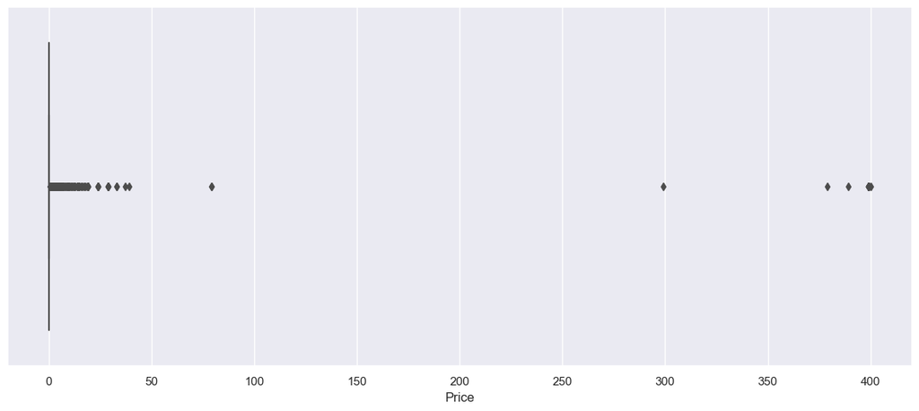

```python
sns.boxplot(x = 'Price', data = google_df)
plt.show()
```

There are some apps whose price is higher than the usual price of the apps

**Boxplot for Reviews**

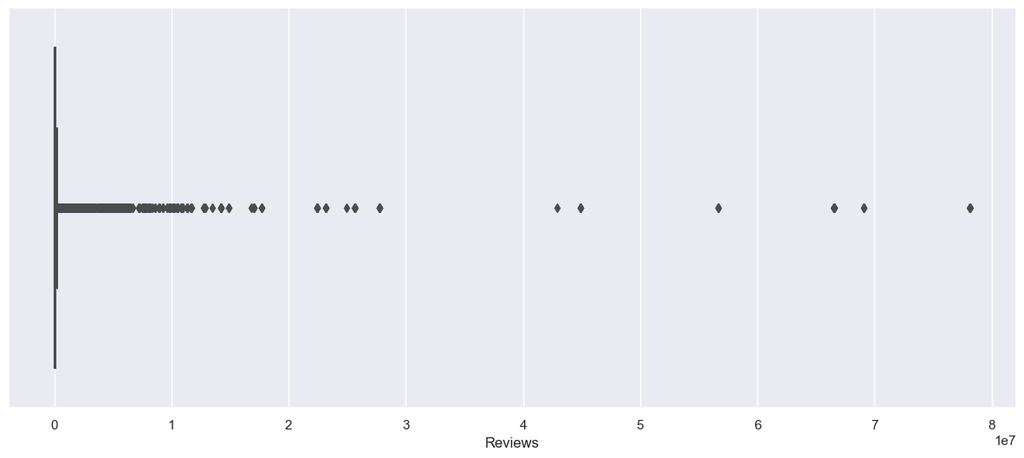

```python
sns.boxplot(x = 'Reviews', data = google_df)
plt.show()
```

There are some apps who have higher number of reviews than the usual apps which are considered to be outliers

**Histogram for Rating**

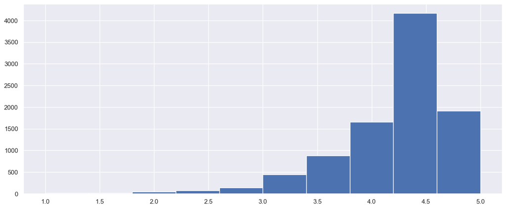

```python
plt.hist(google_df['Rating'])
plt.show()
```

This is a negatively skewed histogram i.e., majority of the apps have higher ratings

**Histogram For Size**

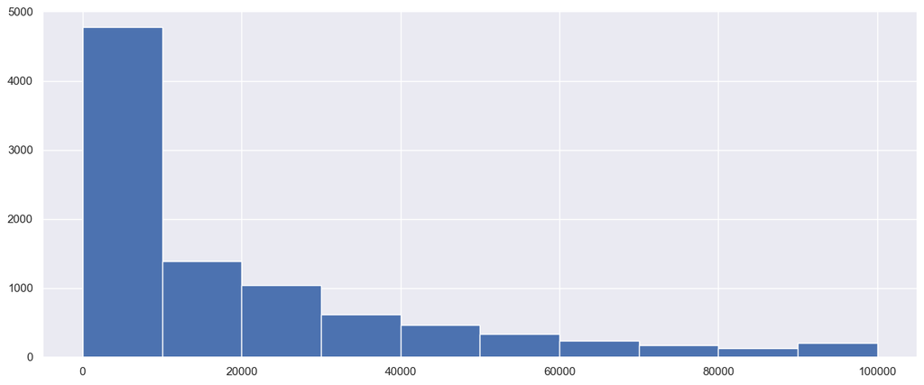

```python
plt.hist(google_df['Size'])
plt.show()
```

This is a positively skewed histogram i.e., majority of the apps have lower app size

# 6. Outlier Treatment

**6.1 Price**

```python
#Dropping the apps whose price is higher than $200 as they are outliers
price_outliers = google_df.loc[google_df['Price'] > 200].shape[0]
print('Number of apps having price more than $200 =', price_outliers)
```

```
Number of apps having price more than $200 = 15
```

yes, $200 for an app is a high price, hence we'll be dropping it

```python
google_df.shape
```

```
(9353, 13)
```

```python
google_df.drop(google_df[google_df['Price'] > 200].index, inplace = True)
```

```python
google_df.shape
```

```
(9338, 13)
```

**6.2 Reviews**

```python
revs = google_df.loc[google_df['Reviews'] > 2000000].shape[0]
print('Number of apps having more than 2 Million Reviews = ', revs)
```

```
Number of apps having more than 2 Million Reviews =  453
```

```python
#we'll be dropping these highly reviewed apps to make the data more appropriate
google_df.drop(google_df[google_df['Reviews'] > 2000000].index, inplace = True)
```

```python
google_df.shape
```

```
(8885, 13)
```

**6.3 Installs**

```python
#Calculating quantiles accordingly

google_df.quantile([0.1, 0.25, 0.50, 0.70, 0.90, 0.95, 0.99])
```

|  | Rating | Reviews | Size | Installs | Price |
| --- | --- | --- | --- | --- | --- |
| 0.10 | 3.5 | 18.00 | 0.0 | 1000.0 | 0.0 |
| 0.25 | 4.0 | 159.00 | 2600.0 | 10000.0 | 0.0 |
| 0.50 | 4.3 | 4290.00 | 9500.0 | 500000.0 | 0.0 |
| 0.70 | 4.5 | 35930.40 | 23000.0 | 1000000.0 | 0.0 |
| 0.90 | 4.7 | 296771.00 | 50000.0 | 10000000.0 | 0.0 |
| 0.95 | 4.8 | 637298.00 | 68000.0 | 10000000.0 | 1.0 |
| 0.99 | 5.0 | 1462800.88 | 95000.0 | 100000000.0 | 7.0 |

```python
#we'll drop the values more than the threshold i.e., 95th percentile
google_df.drop(google_df[google_df['Installs'] > 10000000].index, inplace = True)
```

```python
google_df.shape
```

```
(8496, 13)
```

# 7. Bivariate Analysis

**7.1 Scatter Plot Rating vs Price**

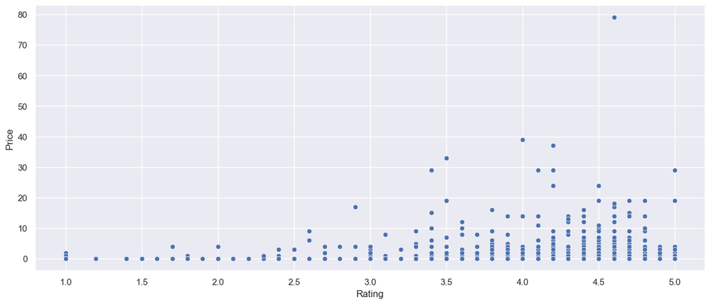

```python
sns.scatterplot(x = 'Rating', y = 'Price', data = google_df)
plt.show()
```

**Joint Plot**

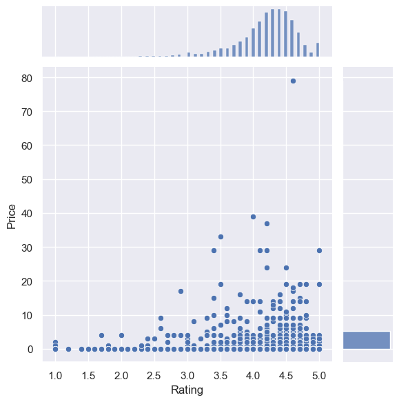

```python
sns.jointplot(x= 'Rating', y = 'Price', data = google_df)
plt.show()
```

**7.2 Scatter Plot for Rating v/s Size**

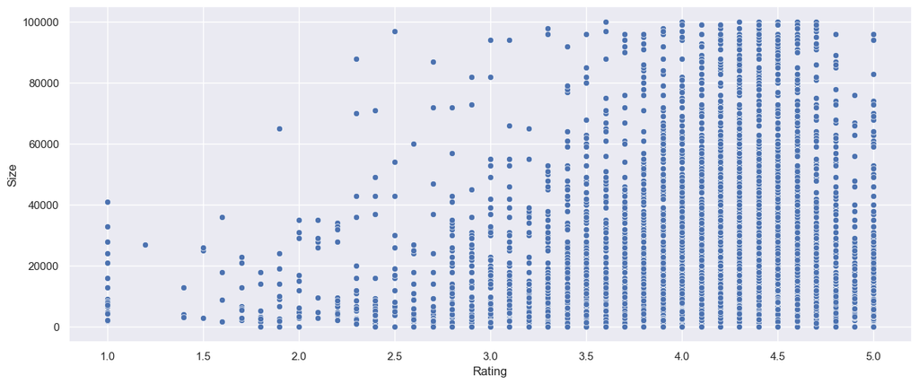

```python
sns.scatterplot(x = 'Rating', y = 'Size', data = google_df)
plt.show()
```

**Joint Plot**

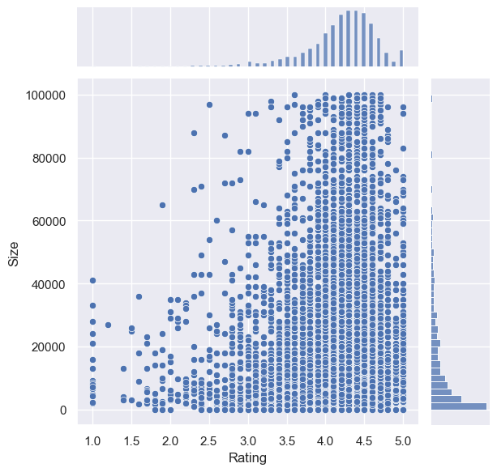

```python
sns.jointplot(x = 'Rating', y = 'Size', data = google_df)
plt.show()
```

**7.3 Scatter Plot for Rating v/s Reviews**

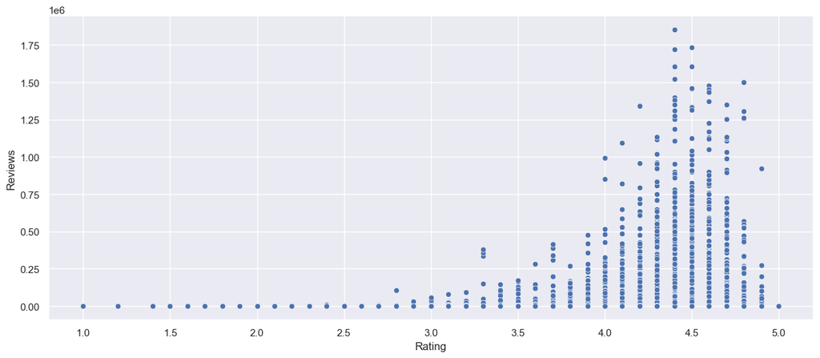

```python
sns.scatterplot(x = 'Rating', y = 'Reviews', data = google_df)
plt.show()
```

**Joint Plot**

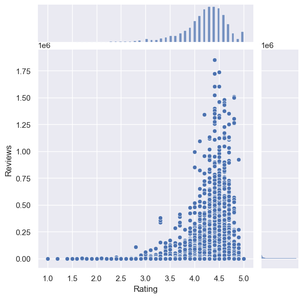

```python
sns.jointplot(x = 'Rating', y = 'Reviews', data = google_df)
plt.show()
```

**7.4 Boxplot for Rating v/s Content Rating**

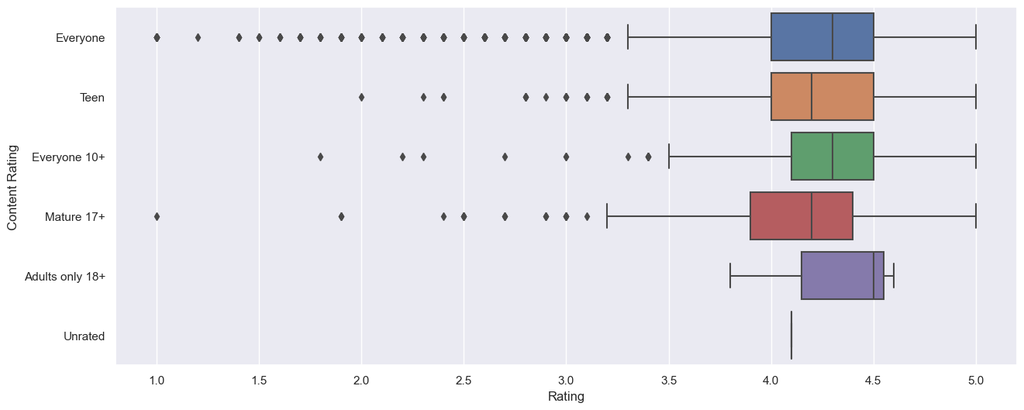

```python
sns.boxplot(x = 'Rating', y = 'Content Rating', data = google_df)
plt.show()
```

Apps for Everyone have the most amount of outliers, there by making them the worst rated apps. Mature 17+, Everyone 10+ and Teen too have some amount of outliers there by falling in the same category. Adult only 18+ apps have no outliers and hence are the most liked apps **Most Liked: Adults only 18+**

**7.5 Boxplot for Rating v/s Category**

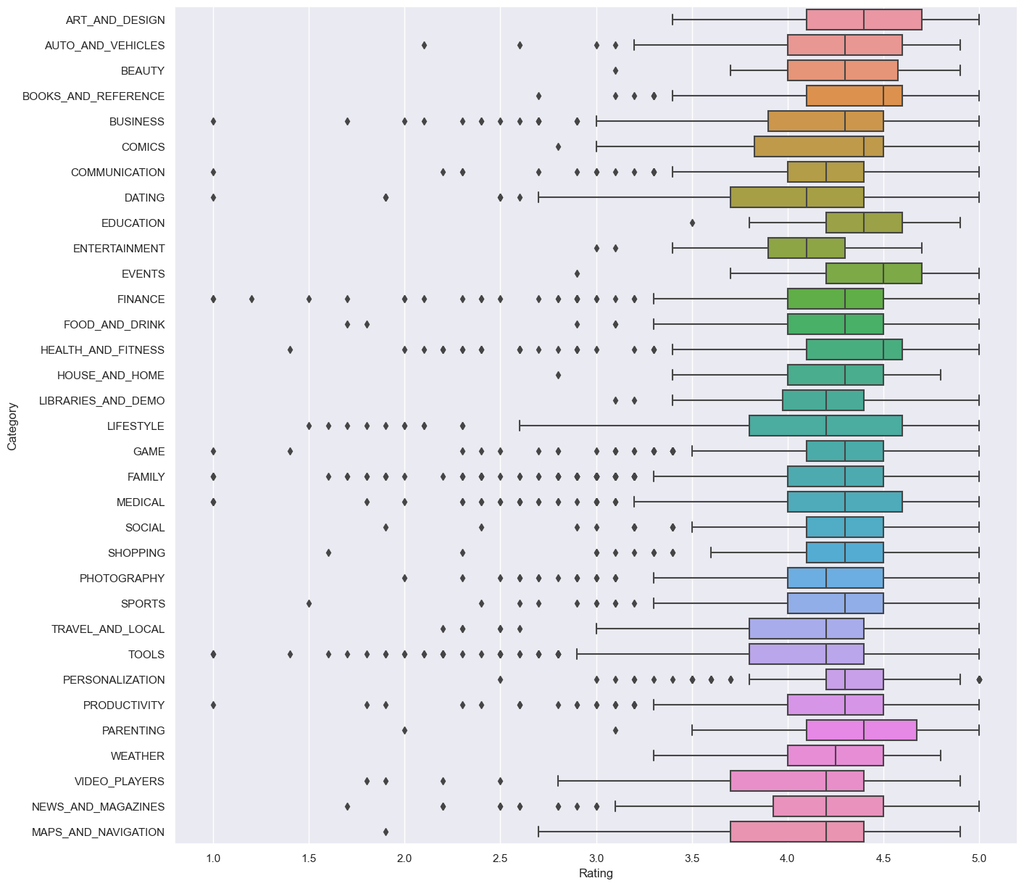

```python
sns.set(rc = {'figure.figsize': (15,15)})
sns.boxplot(x = 'Rating', y = 'Category', data = google_df)
plt.show()
```

# 8. Data Preprocessing

```python
inp1 = google_df.copy() #creating a copy of google_df
```

```python
inp1.head(10)
```

|  | App | Category | Rating | Reviews | Size | Installs | Type | Price | Content Rating | Genres | Last Updated | Current Ver | Android Ver |
| --- | --- | --- | --- | --- | --- | --- | --- | --- | --- | --- | --- | --- | --- |
| 0 | Photo Editor & Candy Camera & Grid & ScrapBook | ART_AND_DESIGN | 4.1 | 159.0 | 19000.0 | 10000 | Free | 0 | Everyone | Art & Design | January 7, 2018 | 1.0.0 | 4.0.3 and up |
| 1 | Coloring book moana | ART_AND_DESIGN | 3.9 | 967.0 | 14000.0 | 500000 | Free | 0 | Everyone | Art & Design;Pretend Play | January 15, 2018 | 2.0.0 | 4.0.3 and up |
| 2 | U Launcher Lite – FREE Live Cool Themes, Hide ... | ART_AND_DESIGN | 4.7 | 87510.0 | 8700.0 | 5000000 | Free | 0 | Everyone | Art & Design | August 1, 2018 | 1.2.4 | 4.0.3 and up |
| 4 | Pixel Draw - Number Art Coloring Book | ART_AND_DESIGN | 4.3 | 967.0 | 2800.0 | 100000 | Free | 0 | Everyone | Art & Design;Creativity | June 20, 2018 | 1.1 | 4.4 and up |
| 5 | Paper flowers instructions | ART_AND_DESIGN | 4.4 | 167.0 | 5600.0 | 50000 | Free | 0 | Everyone | Art & Design | March 26, 2017 | 1.0 | 2.3 and up |
| 6 | Smoke Effect Photo Maker - Smoke Editor | ART_AND_DESIGN | 3.8 | 178.0 | 19000.0 | 50000 | Free | 0 | Everyone | Art & Design | April 26, 2018 | 1.1 | 4.0.3 and up |
| 7 | Infinite Painter | ART_AND_DESIGN | 4.1 | 36815.0 | 29000.0 | 1000000 | Free | 0 | Everyone | Art & Design | June 14, 2018 | 6.1.61.1 | 4.2 and up |
| 8 | Garden Coloring Book | ART_AND_DESIGN | 4.4 | 13791.0 | 33000.0 | 1000000 | Free | 0 | Everyone | Art & Design | September 20, 2017 | 2.9.2 | 3.0 and up |
| 9 | Kids Paint Free - Drawing Fun | ART_AND_DESIGN | 4.7 | 121.0 | 3100.0 | 10000 | Free | 0 | Everyone | Art & Design;Creativity | July 3, 2018 | 2.8 | 4.0.3 and up |
| 10 | Text on Photo - Fonteee | ART_AND_DESIGN | 4.4 | 13880.0 | 28000.0 | 1000000 | Free | 0 | Everyone | Art & Design | October 27, 2017 | 1.0.4 | 4.1 and up |

**8.1 Applying log transformation to 'Reviews' and 'Installs' Columns**

```python
inp1.skew() #To check skewness of the data
```

```
Rating      -1.749753
Reviews      4.576494
Size         1.655917
Installs     1.543697
Price       18.074542
dtype: float64
```

```python
inp1.describe()
```

|  | Rating | Reviews | Size | Installs | Price |
| --- | --- | --- | --- | --- | --- |
| count | 8496.000000 | 8.496000e+03 | 8496.000000 | 8.496000e+03 | 8496.000000 |
| mean | 4.173411 | 6.566228e+04 | 18639.701036 | 2.134612e+06 | 0.299788 |
| std | 0.533032 | 1.680637e+05 | 22158.033336 | 3.525914e+06 | 2.142247 |
| min | 1.000000 | 1.000000e+00 | 0.000000 | 5.000000e+00 | 0.000000 |
| 25% | 4.000000 | 1.340000e+02 | 2900.000000 | 1.000000e+04 | 0.000000 |
| 50% | 4.300000 | 3.325500e+03 | 9800.000000 | 1.000000e+05 | 0.000000 |
| 75% | 4.500000 | 4.205000e+04 | 26000.000000 | 1.000000e+06 | 0.000000 |
| max | 5.000000 | 1.852384e+06 | 100000.000000 | 1.000000e+07 | 79.000000 |

```python
reviews_skew = np.log1p(inp1['Reviews']) #log transformation on Reviews column
inp1['Reviews'] = reviews_skew
```

```python
reviews_skew.skew()
```

```
-0.20039949659264134
```

```python
installs_skew = np.log1p(inp1['Installs']) #log transgormation on Installs column
inp1['Installs'] = installs_skew
```

```python
installs_skew.skew()
```

```
-0.5097286542754812
```

```python
inp1.head(10)
```

|  | App | Category | Rating | Reviews | Size | Installs | Type | Price | Content Rating | Genres | Last Updated | Current Ver | Android Ver |
| --- | --- | --- | --- | --- | --- | --- | --- | --- | --- | --- | --- | --- | --- |
| 0 | Photo Editor & Candy Camera & Grid & ScrapBook | ART_AND_DESIGN | 4.1 | 5.075174 | 19000.0 | 9.210440 | Free | 0 | Everyone | Art & Design | January 7, 2018 | 1.0.0 | 4.0.3 and up |
| 1 | Coloring book moana | ART_AND_DESIGN | 3.9 | 6.875232 | 14000.0 | 13.122365 | Free | 0 | Everyone | Art & Design;Pretend Play | January 15, 2018 | 2.0.0 | 4.0.3 and up |
| 2 | U Launcher Lite – FREE Live Cool Themes, Hide ... | ART_AND_DESIGN | 4.7 | 11.379520 | 8700.0 | 15.424949 | Free | 0 | Everyone | Art & Design | August 1, 2018 | 1.2.4 | 4.0.3 and up |
| 4 | Pixel Draw - Number Art Coloring Book | ART_AND_DESIGN | 4.3 | 6.875232 | 2800.0 | 11.512935 | Free | 0 | Everyone | Art & Design;Creativity | June 20, 2018 | 1.1 | 4.4 and up |
| 5 | Paper flowers instructions | ART_AND_DESIGN | 4.4 | 5.123964 | 5600.0 | 10.819798 | Free | 0 | Everyone | Art & Design | March 26, 2017 | 1.0 | 2.3 and up |
| 6 | Smoke Effect Photo Maker - Smoke Editor | ART_AND_DESIGN | 3.8 | 5.187386 | 19000.0 | 10.819798 | Free | 0 | Everyone | Art & Design | April 26, 2018 | 1.1 | 4.0.3 and up |
| 7 | Infinite Painter | ART_AND_DESIGN | 4.1 | 10.513688 | 29000.0 | 13.815512 | Free | 0 | Everyone | Art & Design | June 14, 2018 | 6.1.61.1 | 4.2 and up |
| 8 | Garden Coloring Book | ART_AND_DESIGN | 4.4 | 9.531844 | 33000.0 | 13.815512 | Free | 0 | Everyone | Art & Design | September 20, 2017 | 2.9.2 | 3.0 and up |
| 9 | Kids Paint Free - Drawing Fun | ART_AND_DESIGN | 4.7 | 4.804021 | 3100.0 | 9.210440 | Free | 0 | Everyone | Art & Design;Creativity | July 3, 2018 | 2.8 | 4.0.3 and up |
| 10 | Text on Photo - Fonteee | ART_AND_DESIGN | 4.4 | 9.538276 | 28000.0 | 13.815512 | Free | 0 | Everyone | Art & Design | October 27, 2017 | 1.0.4 | 4.1 and up |

**8.2 Dropping Non-Usefull columns**

```python
inp1.drop(['App', 'Last Updated', 'Current Ver', 'Android Ver', 'Type'], axis = 1, inplace = True) #for dropping specified columns
```

```python
inp1.head(10)
```

|  | Category | Rating | Reviews | Size | Installs | Price | Content Rating | Genres |
| --- | --- | --- | --- | --- | --- | --- | --- | --- |
| 0 | ART_AND_DESIGN | 4.1 | 5.075174 | 19000.0 | 9.210440 | 0 | Everyone | Art & Design |
| 1 | ART_AND_DESIGN | 3.9 | 6.875232 | 14000.0 | 13.122365 | 0 | Everyone | Art & Design;Pretend Play |
| 2 | ART_AND_DESIGN | 4.7 | 11.379520 | 8700.0 | 15.424949 | 0 | Everyone | Art & Design |
| 4 | ART_AND_DESIGN | 4.3 | 6.875232 | 2800.0 | 11.512935 | 0 | Everyone | Art & Design;Creativity |
| 5 | ART_AND_DESIGN | 4.4 | 5.123964 | 5600.0 | 10.819798 | 0 | Everyone | Art & Design |
| 6 | ART_AND_DESIGN | 3.8 | 5.187386 | 19000.0 | 10.819798 | 0 | Everyone | Art & Design |
| 7 | ART_AND_DESIGN | 4.1 | 10.513688 | 29000.0 | 13.815512 | 0 | Everyone | Art & Design |
| 8 | ART_AND_DESIGN | 4.4 | 9.531844 | 33000.0 | 13.815512 | 0 | Everyone | Art & Design |
| 9 | ART_AND_DESIGN | 4.7 | 4.804021 | 3100.0 | 9.210440 | 0 | Everyone | Art & Design;Creativity |
| 10 | ART_AND_DESIGN | 4.4 | 9.538276 | 28000.0 | 13.815512 | 0 | Everyone | Art & Design |

```python
inp1.shape
```

```
(8496, 8)
```

**8.3 Dummy Encoding to convert Categorical variables to Numeric ones**

```python
inp2 = inp1 #creating a copy of data
```

```python
inp2.head(10)
```

|  | Category | Rating | Reviews | Size | Installs | Price | Content Rating | Genres |
| --- | --- | --- | --- | --- | --- | --- | --- | --- |
| 0 | ART_AND_DESIGN | 4.1 | 5.075174 | 19000.0 | 9.210440 | 0 | Everyone | Art & Design |
| 1 | ART_AND_DESIGN | 3.9 | 6.875232 | 14000.0 | 13.122365 | 0 | Everyone | Art & Design;Pretend Play |
| 2 | ART_AND_DESIGN | 4.7 | 11.379520 | 8700.0 | 15.424949 | 0 | Everyone | Art & Design |
| 4 | ART_AND_DESIGN | 4.3 | 6.875232 | 2800.0 | 11.512935 | 0 | Everyone | Art & Design;Creativity |
| 5 | ART_AND_DESIGN | 4.4 | 5.123964 | 5600.0 | 10.819798 | 0 | Everyone | Art & Design |
| 6 | ART_AND_DESIGN | 3.8 | 5.187386 | 19000.0 | 10.819798 | 0 | Everyone | Art & Design |
| 7 | ART_AND_DESIGN | 4.1 | 10.513688 | 29000.0 | 13.815512 | 0 | Everyone | Art & Design |
| 8 | ART_AND_DESIGN | 4.4 | 9.531844 | 33000.0 | 13.815512 | 0 | Everyone | Art & Design |
| 9 | ART_AND_DESIGN | 4.7 | 4.804021 | 3100.0 | 9.210440 | 0 | Everyone | Art & Design;Creativity |
| 10 | ART_AND_DESIGN | 4.4 | 9.538276 | 28000.0 | 13.815512 | 0 | Everyone | Art & Design |

**Applying Dummy encoding to Category Column**

**Category column**

```python
inp2['Category'].unique() #for knowing the unique values in the category column
```

```
array(['ART_AND_DESIGN', 'AUTO_AND_VEHICLES', 'BEAUTY',
       'BOOKS_AND_REFERENCE', 'BUSINESS', 'COMICS', 'COMMUNICATION',
       'DATING', 'EDUCATION', 'ENTERTAINMENT', 'EVENTS', 'FINANCE',
       'FOOD_AND_DRINK', 'HEALTH_AND_FITNESS', 'HOUSE_AND_HOME',
       'LIBRARIES_AND_DEMO', 'LIFESTYLE', 'GAME', 'FAMILY', 'MEDICAL',
       'SOCIAL', 'SHOPPING', 'PHOTOGRAPHY', 'SPORTS', 'TRAVEL_AND_LOCAL',
       'TOOLS', 'PERSONALIZATION', 'PRODUCTIVITY', 'PARENTING', 'WEATHER',
       'VIDEO_PLAYERS', 'NEWS_AND_MAGAZINES', 'MAPS_AND_NAVIGATION'],
      dtype=object)
```

```python
inp2.Category = pd.Categorical(inp2.Category)

x = inp2[['Category']]
del inp2['Category']

dummies = pd.get_dummies(x, prefix = 'Category')
inp2 = pd.concat([inp2, dummies], axis = 1)
inp2.head(10)
```

|  | Rating | Reviews | Size | Installs | Price | Content Rating | Genres | Category_ART_AND_DESIGN | Category_AUTO_AND_VEHICLES | Category_BEAUTY | ... | Category_PERSONALIZATION | Category_PHOTOGRAPHY | Category_PRODUCTIVITY | Category_SHOPPING | Category_SOCIAL | Category_SPORTS | Category_TOOLS | Category_TRAVEL_AND_LOCAL | Category_VIDEO_PLAYERS | Category_WEATHER |
| --- | --- | --- | --- | --- | --- | --- | --- | --- | --- | --- | --- | --- | --- | --- | --- | --- | --- | --- | --- | --- | --- |
| 0 | 4.1 | 5.075174 | 19000.0 | 9.210440 | 0 | Everyone | Art & Design | 1 | 0 | 0 | ... | 0 | 0 | 0 | 0 | 0 | 0 | 0 | 0 | 0 | 0 |
| 1 | 3.9 | 6.875232 | 14000.0 | 13.122365 | 0 | Everyone | Art & Design;Pretend Play | 1 | 0 | 0 | ... | 0 | 0 | 0 | 0 | 0 | 0 | 0 | 0 | 0 | 0 |
| 2 | 4.7 | 11.379520 | 8700.0 | 15.424949 | 0 | Everyone | Art & Design | 1 | 0 | 0 | ... | 0 | 0 | 0 | 0 | 0 | 0 | 0 | 0 | 0 | 0 |
| 4 | 4.3 | 6.875232 | 2800.0 | 11.512935 | 0 | Everyone | Art & Design;Creativity | 1 | 0 | 0 | ... | 0 | 0 | 0 | 0 | 0 | 0 | 0 | 0 | 0 | 0 |
| 5 | 4.4 | 5.123964 | 5600.0 | 10.819798 | 0 | Everyone | Art & Design | 1 | 0 | 0 | ... | 0 | 0 | 0 | 0 | 0 | 0 | 0 | 0 | 0 | 0 |
| 6 | 3.8 | 5.187386 | 19000.0 | 10.819798 | 0 | Everyone | Art & Design | 1 | 0 | 0 | ... | 0 | 0 | 0 | 0 | 0 | 0 | 0 | 0 | 0 | 0 |
| 7 | 4.1 | 10.513688 | 29000.0 | 13.815512 | 0 | Everyone | Art & Design | 1 | 0 | 0 | ... | 0 | 0 | 0 | 0 | 0 | 0 | 0 | 0 | 0 | 0 |
| 8 | 4.4 | 9.531844 | 33000.0 | 13.815512 | 0 | Everyone | Art & Design | 1 | 0 | 0 | ... | 0 | 0 | 0 | 0 | 0 | 0 | 0 | 0 | 0 | 0 |
| 9 | 4.7 | 4.804021 | 3100.0 | 9.210440 | 0 | Everyone | Art & Design;Creativity | 1 | 0 | 0 | ... | 0 | 0 | 0 | 0 | 0 | 0 | 0 | 0 | 0 | 0 |
| 10 | 4.4 | 9.538276 | 28000.0 | 13.815512 | 0 | Everyone | Art & Design | 1 | 0 | 0 | ... | 0 | 0 | 0 | 0 | 0 | 0 | 0 | 0 | 0 | 0 |

10 rows × 40 columns

**Genres Column**

```python
inp2['Genres'].unique()
```

```
array(['Art & Design', 'Art & Design;Pretend Play',
       'Art & Design;Creativity', 'Auto & Vehicles', 'Beauty',
       'Books & Reference', 'Business', 'Comics', 'Comics;Creativity',
       'Communication', 'Dating', 'Education', 'Education;Creativity',
       'Education;Education', 'Education;Music & Video',
       'Education;Action & Adventure', 'Education;Pretend Play',
       'Education;Brain Games', 'Entertainment',
       'Entertainment;Brain Games', 'Entertainment;Creativity',
       'Entertainment;Music & Video', 'Events', 'Finance', 'Food & Drink',
       'Health & Fitness', 'House & Home', 'Libraries & Demo',
       'Lifestyle', 'Lifestyle;Pretend Play', 'Card', 'Casual', 'Puzzle',
       'Action', 'Arcade', 'Word', 'Racing', 'Casual;Creativity',
       'Sports', 'Board', 'Simulation', 'Role Playing', 'Adventure',
       'Strategy', 'Simulation;Education', 'Action;Action & Adventure',
       'Trivia', 'Casual;Brain Games', 'Simulation;Action & Adventure',
       'Educational;Creativity', 'Puzzle;Brain Games',
       'Educational;Education', 'Card;Brain Games',
       'Educational;Brain Games', 'Educational;Pretend Play',
       'Casual;Action & Adventure', 'Entertainment;Education',
       'Casual;Education', 'Casual;Pretend Play', 'Music;Music & Video',
       'Racing;Action & Adventure', 'Arcade;Pretend Play',
       'Adventure;Action & Adventure', 'Role Playing;Action & Adventure',
       'Simulation;Pretend Play', 'Puzzle;Creativity',
       'Sports;Action & Adventure', 'Educational;Action & Adventure',
       'Arcade;Action & Adventure', 'Entertainment;Action & Adventure',
       'Puzzle;Action & Adventure', 'Strategy;Action & Adventure',
       'Music & Audio;Music & Video', 'Health & Fitness;Education',
       'Adventure;Education', 'Board;Brain Games',
       'Board;Action & Adventure', 'Board;Pretend Play',
       'Casual;Music & Video', 'Role Playing;Pretend Play',
       'Entertainment;Pretend Play', 'Video Players & Editors;Creativity',
       'Card;Action & Adventure', 'Medical', 'Social', 'Shopping',
       'Photography', 'Travel & Local',
       'Travel & Local;Action & Adventure', 'Tools', 'Tools;Education',
       'Personalization', 'Productivity', 'Parenting',
       'Parenting;Music & Video', 'Parenting;Brain Games',
       'Parenting;Education', 'Weather', 'Video Players & Editors',
       'Video Players & Editors;Music & Video', 'News & Magazines',
       'Maps & Navigation', 'Health & Fitness;Action & Adventure',
       'Music', 'Educational', 'Casino', 'Adventure;Brain Games',
       'Lifestyle;Education', 'Books & Reference;Education',
       'Puzzle;Education', 'Role Playing;Brain Games',
       'Strategy;Education', 'Racing;Pretend Play',
       'Communication;Creativity', 'Strategy;Creativity'], dtype=object)
```

We are going to streamline the genres since there are too many genres and will assigning them to a single category called 'Other'

```python
lists = [] #Empty list

for i in inp2.Genres.value_counts().index: #getting total no. of genres and if less than 20 then assigning them to a new category Other
    if inp2.Genres.value_counts()[i] < 20:        lists.append(i)

inp2.Genres = ['Other' if i in lists else i for i in inp2.Genres] #changing the genres to other
```

```python
inp2['Genres'].unique()
```

```
array(['Art & Design', 'Other', 'Auto & Vehicles', 'Beauty',
       'Books & Reference', 'Business', 'Comics', 'Communication',
       'Dating', 'Education', 'Education;Education',
       'Education;Pretend Play', 'Entertainment',
       'Entertainment;Music & Video', 'Events', 'Finance', 'Food & Drink',
       'Health & Fitness', 'House & Home', 'Libraries & Demo',
       'Lifestyle', 'Card', 'Casual', 'Puzzle', 'Action', 'Arcade',
       'Word', 'Racing', 'Sports', 'Board', 'Simulation', 'Role Playing',
       'Adventure', 'Strategy', 'Trivia', 'Educational;Education',
       'Casual;Pretend Play', 'Medical', 'Social', 'Shopping',
       'Photography', 'Travel & Local', 'Tools', 'Personalization',
       'Productivity', 'Parenting', 'Weather', 'Video Players & Editors',
       'News & Magazines', 'Maps & Navigation', 'Educational', 'Casino'],
      dtype=object)
```

```python
inp2.Genres = pd.Categorical(inp2['Genres']) #genres column into x variable
x = inp2[['Genres']]
del inp2['Genres'] #deleting the Genres column

#encoding and storing the dummies values in dataset
dummies = pd.get_dummies(x, prefix = 'Genres')
inp2 = pd.concat([inp2, dummies], axis = 1)
```

```python
inp2.head(10)
```

|  | Rating | Reviews | Size | Installs | Price | Content Rating | Category_ART_AND_DESIGN | Category_AUTO_AND_VEHICLES | Category_BEAUTY | Category_BOOKS_AND_REFERENCE | ... | Genres_Simulation | Genres_Social | Genres_Sports | Genres_Strategy | Genres_Tools | Genres_Travel & Local | Genres_Trivia | Genres_Video Players & Editors | Genres_Weather | Genres_Word |
| --- | --- | --- | --- | --- | --- | --- | --- | --- | --- | --- | --- | --- | --- | --- | --- | --- | --- | --- | --- | --- | --- |
| 0 | 4.1 | 5.075174 | 19000.0 | 9.210440 | 0 | Everyone | 1 | 0 | 0 | 0 | ... | 0 | 0 | 0 | 0 | 0 | 0 | 0 | 0 | 0 | 0 |
| 1 | 3.9 | 6.875232 | 14000.0 | 13.122365 | 0 | Everyone | 1 | 0 | 0 | 0 | ... | 0 | 0 | 0 | 0 | 0 | 0 | 0 | 0 | 0 | 0 |
| 2 | 4.7 | 11.379520 | 8700.0 | 15.424949 | 0 | Everyone | 1 | 0 | 0 | 0 | ... | 0 | 0 | 0 | 0 | 0 | 0 | 0 | 0 | 0 | 0 |
| 4 | 4.3 | 6.875232 | 2800.0 | 11.512935 | 0 | Everyone | 1 | 0 | 0 | 0 | ... | 0 | 0 | 0 | 0 | 0 | 0 | 0 | 0 | 0 | 0 |
| 5 | 4.4 | 5.123964 | 5600.0 | 10.819798 | 0 | Everyone | 1 | 0 | 0 | 0 | ... | 0 | 0 | 0 | 0 | 0 | 0 | 0 | 0 | 0 | 0 |
| 6 | 3.8 | 5.187386 | 19000.0 | 10.819798 | 0 | Everyone | 1 | 0 | 0 | 0 | ... | 0 | 0 | 0 | 0 | 0 | 0 | 0 | 0 | 0 | 0 |
| 7 | 4.1 | 10.513688 | 29000.0 | 13.815512 | 0 | Everyone | 1 | 0 | 0 | 0 | ... | 0 | 0 | 0 | 0 | 0 | 0 | 0 | 0 | 0 | 0 |
| 8 | 4.4 | 9.531844 | 33000.0 | 13.815512 | 0 | Everyone | 1 | 0 | 0 | 0 | ... | 0 | 0 | 0 | 0 | 0 | 0 | 0 | 0 | 0 | 0 |
| 9 | 4.7 | 4.804021 | 3100.0 | 9.210440 | 0 | Everyone | 1 | 0 | 0 | 0 | ... | 0 | 0 | 0 | 0 | 0 | 0 | 0 | 0 | 0 | 0 |
| 10 | 4.4 | 9.538276 | 28000.0 | 13.815512 | 0 | Everyone | 1 | 0 | 0 | 0 | ... | 0 | 0 | 0 | 0 | 0 | 0 | 0 | 0 | 0 | 0 |

10 rows × 91 columns

**Content Rating Column**

```python
inp2['Content Rating'].unique()
```

```
array(['Everyone', 'Teen', 'Everyone 10+', 'Mature 17+',
       'Adults only 18+', 'Unrated'], dtype=object)
```

```python
inp2['Content Rating'] = pd.Categorical(inp2['Content Rating'])

x = inp2[['Content Rating']]
del inp2['Content Rating']

dummies = pd.get_dummies(x, prefix = 'Content Rating')
inp2 = pd.concat([inp2, dummies], axis = 1)
inp2.head(10)
```

|  | Rating | Reviews | Size | Installs | Price | Category_ART_AND_DESIGN | Category_AUTO_AND_VEHICLES | Category_BEAUTY | Category_BOOKS_AND_REFERENCE | Category_BUSINESS | ... | Genres_Trivia | Genres_Video Players & Editors | Genres_Weather | Genres_Word | Content Rating_Adults only 18+ | Content Rating_Everyone | Content Rating_Everyone 10+ | Content Rating_Mature 17+ | Content Rating_Teen | Content Rating_Unrated |
| --- | --- | --- | --- | --- | --- | --- | --- | --- | --- | --- | --- | --- | --- | --- | --- | --- | --- | --- | --- | --- | --- |
| 0 | 4.1 | 5.075174 | 19000.0 | 9.210440 | 0 | 1 | 0 | 0 | 0 | 0 | ... | 0 | 0 | 0 | 0 | 0 | 1 | 0 | 0 | 0 | 0 |
| 1 | 3.9 | 6.875232 | 14000.0 | 13.122365 | 0 | 1 | 0 | 0 | 0 | 0 | ... | 0 | 0 | 0 | 0 | 0 | 1 | 0 | 0 | 0 | 0 |
| 2 | 4.7 | 11.379520 | 8700.0 | 15.424949 | 0 | 1 | 0 | 0 | 0 | 0 | ... | 0 | 0 | 0 | 0 | 0 | 1 | 0 | 0 | 0 | 0 |
| 4 | 4.3 | 6.875232 | 2800.0 | 11.512935 | 0 | 1 | 0 | 0 | 0 | 0 | ... | 0 | 0 | 0 | 0 | 0 | 1 | 0 | 0 | 0 | 0 |
| 5 | 4.4 | 5.123964 | 5600.0 | 10.819798 | 0 | 1 | 0 | 0 | 0 | 0 | ... | 0 | 0 | 0 | 0 | 0 | 1 | 0 | 0 | 0 | 0 |
| 6 | 3.8 | 5.187386 | 19000.0 | 10.819798 | 0 | 1 | 0 | 0 | 0 | 0 | ... | 0 | 0 | 0 | 0 | 0 | 1 | 0 | 0 | 0 | 0 |
| 7 | 4.1 | 10.513688 | 29000.0 | 13.815512 | 0 | 1 | 0 | 0 | 0 | 0 | ... | 0 | 0 | 0 | 0 | 0 | 1 | 0 | 0 | 0 | 0 |
| 8 | 4.4 | 9.531844 | 33000.0 | 13.815512 | 0 | 1 | 0 | 0 | 0 | 0 | ... | 0 | 0 | 0 | 0 | 0 | 1 | 0 | 0 | 0 | 0 |
| 9 | 4.7 | 4.804021 | 3100.0 | 9.210440 | 0 | 1 | 0 | 0 | 0 | 0 | ... | 0 | 0 | 0 | 0 | 0 | 1 | 0 | 0 | 0 | 0 |
| 10 | 4.4 | 9.538276 | 28000.0 | 13.815512 | 0 | 1 | 0 | 0 | 0 | 0 | ... | 0 | 0 | 0 | 0 | 0 | 1 | 0 | 0 | 0 | 0 |

10 rows × 96 columns

# 9. Train and Test Splitting the Data

# 10. Separating the df into "X_train, X_test, y_train, y_test"

```python
from sklearn.model_selection import train_test_split as tts
from sklearn.linear_model import LinearRegression as LR
from sklearn.metrics import mean_squared_error as mse
from sklearn import metrics
```

Creating X and Y variables; X = Independent Features; Y = Target Feature

```python
ml1 = inp2
X = ml1.drop('Rating', axis = 1)
y = ml1['Rating']

X_train, X_test, y_train, y_test = tts(X, y, test_size = 0.3, random_state = 5)
```

```python
print('Shape of X_train =', X_train.shape)
print('Shape of X_test =', X_test.shape)
print('Shape of y_train =', y_train.shape)
print('Shape of y_test =', y_test.shape)
```

```
Shape of X_train = (5947, 95)
Shape of X_test = (2549, 95)
Shape of y_train = (5947,)
Shape of y_test = (2549,)
```

# 11. Model Building

**11.1 Linear Regression Model Used**

```python
#Using Linear Regression technique
lr = LR()
lr.fit(X_train, y_train) #lr = LinearRegression
```

```
LinearRegression()
```

```python
print("Intercept of Linear Regression Model = ", lr.intercept_)
```

```
Intercept of Linear Regression Model =  4.60580786346828
```

```python
print("Column Names for Co-Efficient =", ml1.columns)
print("Co-Efficient of Linear Regression Model = ", lr.coef_)
```

```
Column Names for Co-Efficient = Index(['Rating', 'Reviews', 'Size', 'Installs', 'Price',
       'Category_ART_AND_DESIGN', 'Category_AUTO_AND_VEHICLES',
       'Category_BEAUTY', 'Category_BOOKS_AND_REFERENCE', 'Category_BUSINESS',
       'Category_COMICS', 'Category_COMMUNICATION', 'Category_DATING',
       'Category_EDUCATION', 'Category_ENTERTAINMENT', 'Category_EVENTS',
       'Category_FAMILY', 'Category_FINANCE', 'Category_FOOD_AND_DRINK',
       'Category_GAME', 'Category_HEALTH_AND_FITNESS',
       'Category_HOUSE_AND_HOME', 'Category_LIBRARIES_AND_DEMO',
       'Category_LIFESTYLE', 'Category_MAPS_AND_NAVIGATION',
       'Category_MEDICAL', 'Category_NEWS_AND_MAGAZINES', 'Category_PARENTING',
       'Category_PERSONALIZATION', 'Category_PHOTOGRAPHY',
       'Category_PRODUCTIVITY', 'Category_SHOPPING', 'Category_SOCIAL',
       'Category_SPORTS', 'Category_TOOLS', 'Category_TRAVEL_AND_LOCAL',
       'Category_VIDEO_PLAYERS', 'Category_WEATHER', 'Genres_Action',
       'Genres_Adventure', 'Genres_Arcade', 'Genres_Art & Design',
       'Genres_Auto & Vehicles', 'Genres_Beauty', 'Genres_Board',
       'Genres_Books & Reference', 'Genres_Business', 'Genres_Card',
       'Genres_Casino', 'Genres_Casual', 'Genres_Casual;Pretend Play',
       'Genres_Comics', 'Genres_Communication', 'Genres_Dating',
       'Genres_Education', 'Genres_Education;Education',
       'Genres_Education;Pretend Play', 'Genres_Educational',
       'Genres_Educational;Education', 'Genres_Entertainment',
       'Genres_Entertainment;Music & Video', 'Genres_Events', 'Genres_Finance',
       'Genres_Food & Drink', 'Genres_Health & Fitness', 'Genres_House & Home',
       'Genres_Libraries & Demo', 'Genres_Lifestyle',
       'Genres_Maps & Navigation', 'Genres_Medical', 'Genres_News & Magazines',
       'Genres_Other', 'Genres_Parenting', 'Genres_Personalization',
       'Genres_Photography', 'Genres_Productivity', 'Genres_Puzzle',
       'Genres_Racing', 'Genres_Role Playing', 'Genres_Shopping',
       'Genres_Simulation', 'Genres_Social', 'Genres_Sports',
       'Genres_Strategy', 'Genres_Tools', 'Genres_Travel & Local',
       'Genres_Trivia', 'Genres_Video Players & Editors', 'Genres_Weather',
       'Genres_Word', 'Content Rating_Adults only 18+',
       'Content Rating_Everyone', 'Content Rating_Everyone 10+',
       'Content Rating_Mature 17+', 'Content Rating_Teen',
       'Content Rating_Unrated'],
      dtype='object')
Co-Efficient of Linear Regression Model =  [ 1.68256363e-01 -2.47347822e-07 -1.46581249e-01 -6.66160859e-03
  2.63701150e-01  2.86399399e-02  1.04832338e-01  8.47591518e-02
 -2.49959598e-02  5.89649542e-01 -4.73081404e-02 -8.75145016e-02
 -3.13758400e-02 -1.39088486e-01  1.04840295e-01 -4.45665098e-02
 -4.08280775e-02 -3.50576566e-02  3.77419737e-02  1.64348690e-02
  3.09614942e-02  3.99343726e-02 -3.55609165e-01 -7.28587645e-02
  1.53608834e-02 -1.70915126e-02  6.30861974e-02  5.15725201e-02
 -1.73077202e-02  2.60592072e-03  3.03657409e-02  1.89925185e-02
 -3.16031225e-02 -2.95981288e-02 -1.01420074e-01 -3.97135111e-01
 -1.01201362e-02 -7.16690415e-02 -1.80941104e-01 -1.55145133e-02
  4.31534631e-02  2.86399399e-02  1.04832338e-01 -8.01139563e-02
  8.47591518e-02 -2.49959598e-02 -1.73783445e-01  3.11932127e-02
 -6.51020737e-02 -1.81950411e-02 -6.40652372e-01 -4.73081404e-02
 -8.75145016e-02  1.66357424e-01  3.23303460e-01  2.34489902e-01
 -2.62606003e-01  2.59852679e-01 -6.11477541e-03 -7.83335480e-04
  1.04840295e-01 -4.08280775e-02 -3.50576566e-02  1.64348690e-02
  3.09614942e-02  3.99343726e-02  2.83431978e-01 -7.28587645e-02
  1.53608834e-02 -1.70915126e-02  1.36688202e-01  1.21123366e-01
  5.15725201e-02 -1.73077202e-02  2.60592072e-03  1.56930801e-01
 -1.72484519e-01 -2.56916738e-02  3.03657409e-02 -2.90760300e-02
  1.89925185e-02 -3.16031225e-02 -1.00715671e-01 -1.01924660e-01
  8.30174856e-03 -3.17413548e-01  2.45417126e-01 -1.01201362e-02
  1.07923949e-01  3.87512538e-02  5.52914475e-03 -3.08574506e-02
 -2.54497753e-02 -1.01328537e-02  2.21596810e-02]
```

**11.2 R2 on Train Dataset**

```python
R2score_train = round(lr.score(X_train, y_train), 3)

print("R2 Score for the Training Data Set is", R2score_train)
```

```
R2 Score for the Training Data Set is 0.157
```

# 12. Predictions on Test Set

```python
y_test_pred = lr.predict(X_test)

pd.DataFrame({'Actual y_test' : y_test,
             'Predict y_test' : y_test_pred}).head(25)
```

|  | Actual y_test | Predict y_test |
| --- | --- | --- |
| 10720 | 4.4 | 4.260388 |
| 8766 | 4.4 | 4.270425 |
| 601 | 3.9 | 3.903414 |
| 5018 | 3.9 | 4.068528 |
| 2365 | 4.6 | 3.857821 |
| 45 | 4.7 | 4.580476 |
| 3841 | 4.3 | 4.149186 |
| 10017 | 3.8 | 4.063879 |
| 4019 | 3.7 | 3.894693 |
| 7019 | 4.5 | 4.068653 |
| 19 | 4.6 | 4.621031 |
| 8519 | 4.0 | 4.315640 |
| 4165 | 3.4 | 4.225490 |
| 8856 | 4.6 | 4.420731 |
| 7927 | 3.8 | 3.977881 |
| 7327 | 4.4 | 4.130030 |
| 8473 | 3.7 | 4.316438 |
| 1166 | 4.6 | 4.332419 |
| 1334 | 4.6 | 4.426608 |
| 9366 | 4.6 | 3.927775 |
| 10564 | 5.0 | 4.478557 |
| 3860 | 4.3 | 3.975022 |
| 5668 | 4.0 | 4.153535 |
| 5758 | 4.4 | 3.898609 |
| 6698 | 4.5 | 4.498813 |

```python
R2score_test = round(lr.score(X_test, y_test), 3)

print("R2 Score for the Test Data Set is", R2score_test)
```

```
R2 Score for the Test Data Set is 0.141
```